# Project 3 Code

James Chun, Haoming Chen, Pricilla Nakyazze

## Libraries

Load libraries and packages as necessary.

```r
library(tidyverse)
library(DBI)
library(RCurl)
library(stringr)
```

## Import Raw Data The original sources, as stated in the proposal, are found on the following sites:  
https://www.kaggle.com/datasets/arshkon/linkedin-job-postings/data  
https://www.kaggle.com/datasets/asaniczka/data-science-job-postings-and-skills/data

Note that not all provided datasets from the orignal sources were used. As the priority of this project are the job postings and their respective job skills, files not relevant were excluded.

*As of now, the relevant datasets are stored in a github repo and accessed/imported as raw github file.* Note that the postings.csv from the LinkedIn Data takes considerable time to import using this method. For better performance, suggest downloading the “posting.csv” and using read.csv

```r
# "Data Science Postings (2024)" Dataset

DS_job_postings <- getURL("https://media.githubusercontent.com/media/Ryungje/DATA607/refs/heads/main/Project%203/Data%20Science%20Job%20Postings/job_postings.csv") %>%
  read.csv(text = .)

DS_job_skills <- getURL("https://media.githubusercontent.com/media/Ryungje/DATA607/refs/heads/main/Project%203/Data%20Science%20Job%20Postings/job_skills.csv") %>%
  read.csv(text = .)


# "LinkedIn Postings (2023-2024)" Dataset

# raw github import version
# LI_job_postings <- getURL("https://media.githubusercontent.com/media/Ryungje/DATA607/refs/heads/main/Project%203/LinkedIn%20Job%20Postings/postings.csv") %>%
#  read.csv(text = .)

# importing from local machine for performance
LI_job_postings <- read.csv("LinkedIn Job Postings/postings.csv")

LI_job_skills <- getURL("https://media.githubusercontent.com/media/Ryungje/DATA607/refs/heads/main/Project%203/LinkedIn%20Job%20Postings/job_skills.csv") %>%
  read.csv(text = .)

LI_skill_codes <- getURL("https://media.githubusercontent.com/media/Ryungje/DATA607/refs/heads/main/Project%203/LinkedIn%20Job%20Postings/skills.csv") %>%
  read.csv(text = .)
```

## Data Tidying

### A Brief Description of Datasets:

*DS_job_postings* contains the first set of job postings, with notable information such as *job_link*, *company*, *job_location*, *job_level*, and *job_type*.

*DS_job_skills* contains the respective job skills for each listing in *job_posting*. They are relate to each other through *job_link*. The skills are presented in a single string, which will require further work to parse each individual skill.

*LI_job_postings* contains the second set of job postings, with notable information such as *job_id*, *company_name*, *title*, *location*, *remote_allowed*,

*LI_job_skills* contains the skills with respect to each job presented in *LI_job_postings*. This dataset is in proper long form, where jobs with multiple skills repeats the *job_id* and posts each skill in *skill_abr*.

*LI_skill_codes* contains the mappings for *skill_abr* and their respective skill names

### General Tidying

Work will first be done to tidy *DS_job_postings*. We will be keeping only select columns in *DS_job_postings* and merging in information from *DS_job_skills*. We will also split the skill strings and, thus, elongate *DS_job_postings*.

```r
# Keep desired columns
DS_job_postings <- DS_job_postings %>%
  select(c(job_link, company, job_location, job_level, job_type))

# Merge data from DS_job_skills into DS_job_postings
DS_job_postings <- left_join(DS_job_postings, DS_job_skills, by = "job_link")

# Convert DS_job_postings to long format
DS_job_postings <- DS_job_postings %>%
  mutate(job_skills = str_split(job_skills, ",")) %>%  # Split skill string into list
  unnest(job_skills) %>%                               # Expand list into rows
  mutate(job_skills = str_trim(job_skills)) %>%        # Trim whitespace
  mutate(job_skills = str_to_title(job_skills))        # Tidy skills to be capitalized

# Also convert DS_job_skills to long
DS_job_skills <- DS_job_skills %>%
  mutate(job_skills = str_split(job_skills, ",")) %>%  # Split skill string into list
  unnest(job_skills) %>%                               # Expand list into rows
  mutate(job_skills = str_trim(job_skills)) %>%        # Trim whitespace
  mutate(job_skills = str_to_title(job_skills))        # Tidy skills to be capitalized
```

We will then work on tidying *LI_job_postings*. First, we will edit *LI_job_skills* to represent the actual names and not *skill_abr*. Secondly, we will merge the respective skills into *jobs_postings2* according to *job_id*. Lastly, we will trim the unneeded columns from *LI_job_postings*.

```r
# Replace the skill_abr with actual names
LI_job_postings <- LI_job_skills %>%
  left_join(LI_skill_codes, by = "skill_abr") %>%
  select(job_id, skill_name)   %>%                # Keep only job_id and full skill name
  right_join(LI_job_postings, by = "job_id") %>%    # merge into postings
  select(c(job_id, company_name, title, location, remote_allowed, skill_name)) %>%
  rename(job_skills = skill_name)

# Quick column rename
LI_job_skills <- LI_job_skills %>%
  left_join(LI_skill_codes, by = "skill_abr") %>%
  select(job_id, skill_name) %>%
  rename(job_skills = skill_name)
```

Note that not all entries from *LI_job_skills* was merged into *LI_job_postings* due to the latter not having an associated posting for the former.  
The main datasets now are *DS_job_postings* and *LI_job_postings*, with supplementary sets *DS_job_skills* and *LI_job_skills*, respectively.

## Data Analysis

Now that the data is tidied, we can proceed with some data analysis.

### Bar Graph Function

Going to be making a lot of bar graphs, so will define a function for repetitive use.

```r
bar_graph <- function(data, col, xlab, title_, caption_="", color){
  data %>%
    # Count top ten most frequent
    count({{col}}, sort = TRUE) %>%
    slice_head(n = 10) %>%

    # Make graph
    ggplot(aes(x = reorder({{col}}, n), y = n)) +
    geom_bar(stat = "identity", fill = color) +
    coord_flip() +

    # Make labels
    labs(x= xlab,
         y = "Count",
         title = title_,
         caption = caption_) +

    # Caption customization
    theme(
      plot.caption = element_text(
        hjust = 0.5,        # 0 = left, 0.5 = center, 1 = right
        face = "italic",  # style (e.g., italic, bold)
        size = 10
      )
    )
}
```

### Quick Graphs

The following two graphs are simple bar graphs which display the most frequently appearing skills from each data set.

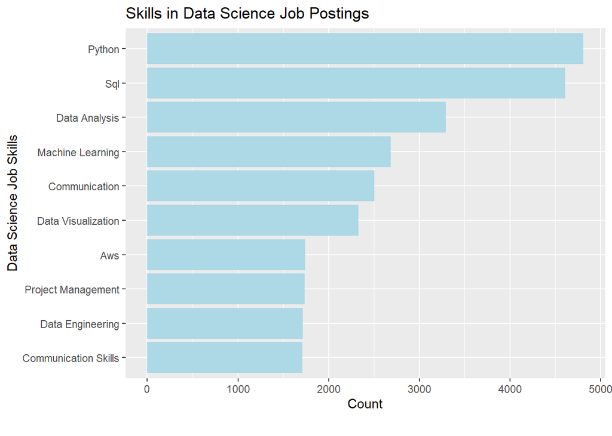

```r
bar_graph(DS_job_skills, job_skills,
          xlab="Data Science Job Skills",
          title_="Skills in Data Science Job Postings",
          color="lightblue")
```

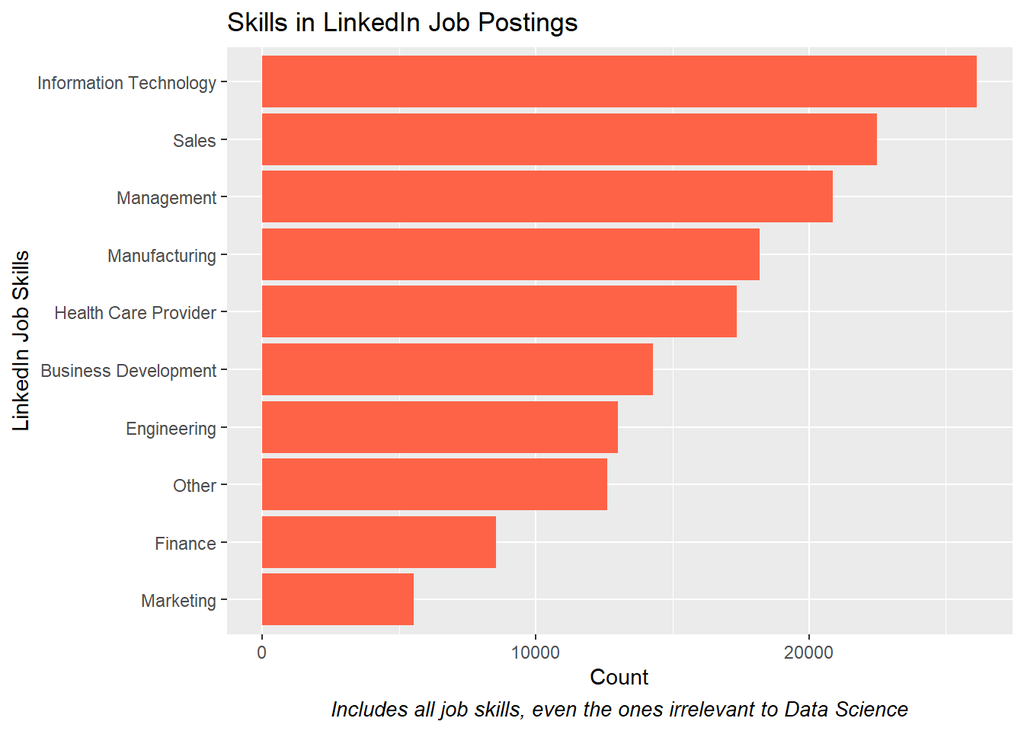

```r
# LinkedIn Skills
bar_graph(LI_job_skills, job_skills,
          xlab="LinkedIn Job Skills",
          title_="Skills in LinkedIn Job Postings",
          caption_="Includes all job skills, even the ones irrelevant to Data Science",
          color="tomato")
```

In this next graph we filter job skills from *DS_job_postings* that specifically mention “Data” and present the top ten.

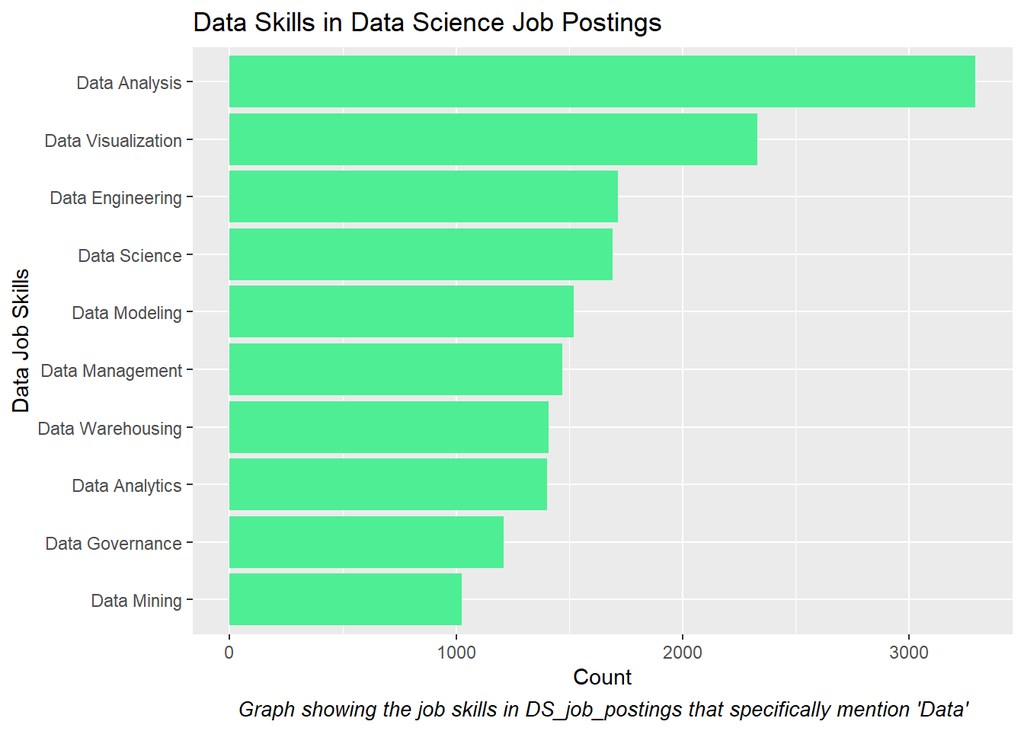

```r
DS_job_postings %>%
  filter(str_detect(job_skills, "Data")) %>%

  bar_graph(job_skills,
          xlab="Data Job Skills",
          title_="Data Skills in Data Science Job Postings",
          caption_="Graph showing the job skills in DS_job_postings that specifically mention 'Data'",
          color="seagreen2")
```